Back to Article

###### ESS330_ProjProposals

Download Source

# ESS330_ProjProposals

Authors

Affiliation

Cameron McLaughlin

The University

Alex Smilor

The University

# Lab 7 Project Kickoff

## Github: CamGit12/ESS330ProjectProposals

### Title: Elwha River - Glines Canyon Dam Removal Effects; Turbidity and Discharge

### Introduction, Background, Motivation

Though river restoration is often one of the goals of dam removal, especially in recent years, the consequences of dam removal are nuanced, with both benefits and costs that must be considered prior to and following dam removal efforts (Duda et al., 2008). Dam removal is known to have impacts on the physical and biological properties of river systems, with potential consequences for river health, human health, local economy and biodiversity. Removing dams can often serve as an important step in reconnecting riparian habitats, allowing for the flooding of wetlands and creating a more complex and better connected riparian habitat matrix that can benefit some species such as wide ranging terrestrial species and species reliant on the presence of ephemeral water bodies (Bednarek, 2001). Dam removal can also improve the connectivity of aquatic habitats, allowing fish and aquatic invertebrates to travel freely up and downstream, often benefiting migratory fish such as salmon (Bednarek, 2001). Physical properties, such as temperature, are also often affected by dam removal. Dams often lead to a decrease in water temperature downstream of the river, since many dams draw water from the cooler depths of their reservoirs (Bednarek, 2001). Removal, therefore, is often an effective method of restoring river water temperatures to their natural state. Additionally, sediment transport often changes following dam removal as previously trapped sediment is released. However, how sediment transport changes is highly variable, with some streams seeing increases in sediment mobilization immediately following dam removal and others not seeing much mobilization until months following removal Johnson (2001).

## EDA

### Project Libraries

```
In [1]:
```

```r
#Libraries
library(dplyr)
library(lubridate)
library(dataRetrieval)
library(tidyr)
library(ggplot2)
library(readr)
library(ggpubr)
library(tidyverse)
library(plotly)
```

### Clean and Prep Data

```
In [2]:
```

```r
#Clean and Prep
raw_turbidity <- readNWISuv("12046260", "63682", startDate = "2013-09-18", endDate = "2019-12-19", tz = "UTC")
```

```
GET:https://nwis.waterservices.usgs.gov/nwis/iv/?site=12046260&format=waterml%2C1.1&ParameterCd=63682&startDT=2013-09-18&endDT=2019-12-19
```

```r
raw_discharge <- readNWISuv("12045500", "00060", startDate = "2013-09-18", endDate = "2019-12-19", tz = "UTC")
```

```
GET:https://nwis.waterservices.usgs.gov/nwis/iv/?site=12045500&format=waterml%2C1.1&ParameterCd=00060&startDT=2013-09-18&endDT=2019-12-19
```

```r
#cleaned

turbidity_clean <- raw_turbidity %>%
  rename(turbidity_fbu = X_63682_00000) %>%
  select(-agency_cd, -site_no, -tz_cd, -X_63682_00000_cd)

  discharge_clean <- raw_discharge %>%
  rename(discharge_cfs = X_00060_00000) %>%
    select(-agency_cd, -site_no, -tz_cd, -X_00060_00000_cd)

#join data frames by datetime
#keep only rows that match 1:1 by datetime

joined_data <- inner_join(discharge_clean, turbidity_clean, by = "dateTime")
```

Our data is directly imported using the USGS dataRetrieval tool. Our data comes in directly through this tool as a csv, with various non-human readable column names. This code eliminates many of the unnecessary columns such as agency, site number, time zone, etc. Additionally, we have implemented renaming to name the correct parameter columns with their appropriate titles and units, Ultimately, our two dataframe with our two parameters needed to be joined so that we can run initial analyses and visualizations to inspect our complete dataset.

### Initial Visualizations and EDA

```
In [3]:
```

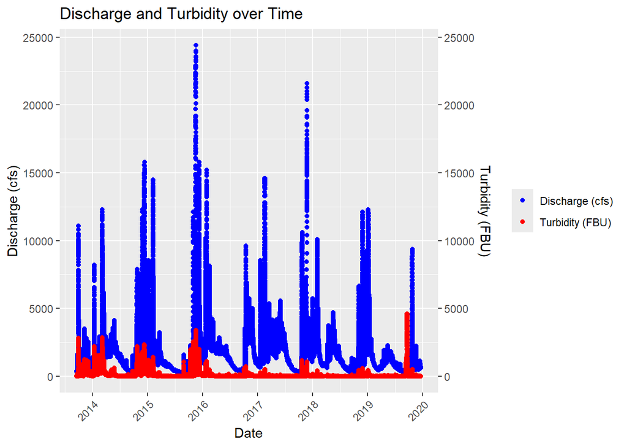

```r
#Both Parameters Plotted, discharge Y-left, Turbidity Y-right
plot1 <- ggplot(joined_data, aes(x = dateTime)) +
  geom_point(aes(y = discharge_cfs, color = "Discharge (cfs)")) +
  geom_point(aes(y = turbidity_fbu, color = "Turbidity (FBU)")) +scale_y_continuous(name = "Discharge (cfs)", sec.axis = sec_axis(~ ., name = "Turbidity (FBU)")) + scale_x_datetime(date_labels = "%Y", date_breaks = "1 year") +
  labs(title = "Discharge and Turbidity over Time", x = "Date") +
  theme(axis.text.x = element_text(angle = 45, hjust = 1)) +
  scale_color_manual(values = c("Discharge (cfs)" = "blue", "Turbidity (FBU)" = "red")) +
  theme(legend.title=element_blank())

print(plot1)
```

```r
#Summarize
summary(joined_data)
```

```
    dateTime                      discharge_cfs   turbidity_fbu
 Min.   :2013-09-18 08:00:00.00   Min.   :  213   Min.   :   0.00
 1st Qu.:2015-03-29 22:03:45.00   1st Qu.:  588   1st Qu.:   5.00
 Median :2016-10-31 04:37:30.00   Median : 1140   Median :  12.30
 Mean   :2016-11-01 21:18:51.89   Mean   : 1496   Mean   :  88.03
 3rd Qu.:2018-06-13 18:26:15.00   3rd Qu.: 1930   3rd Qu.:  47.00
 Max.   :2019-12-19 18:30:00.00   Max.   :24400   Max.   :4590.00
```

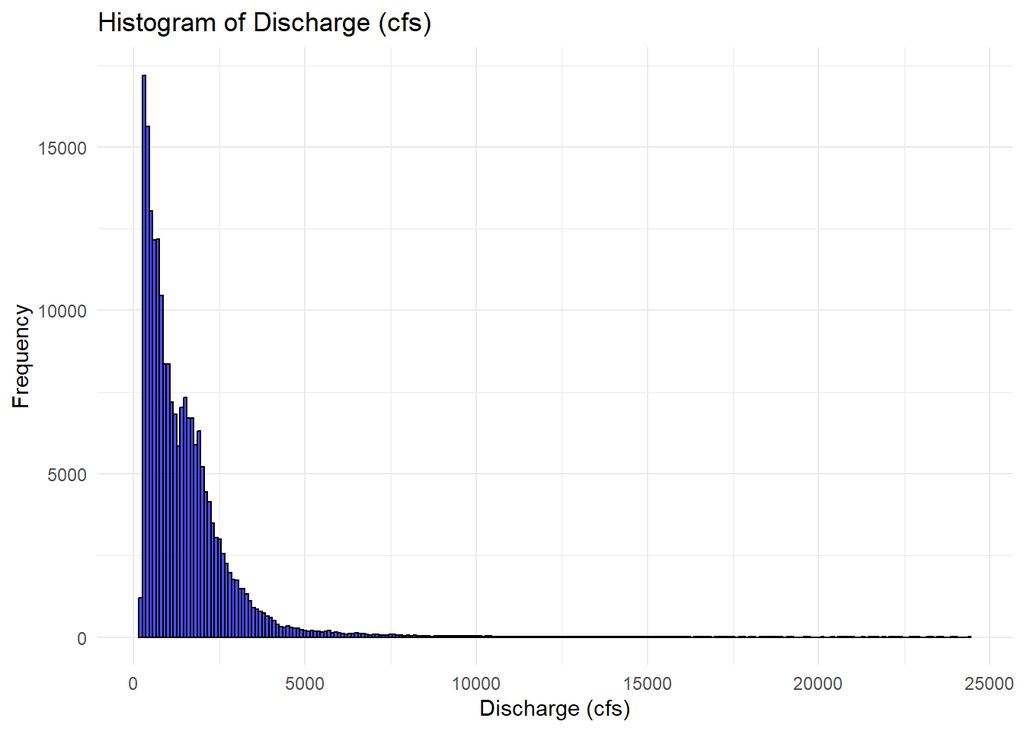

```r
# Histograms for distribution, discharge and turbidity
ggplot(joined_data, aes(x = discharge_cfs)) +
  geom_histogram(binwidth = 100, fill = "blue", color = "black", alpha = 0.7) +
  labs(title = "Histogram of Discharge (cfs)", x = "Discharge (cfs)", y = "Frequency") +
  theme_minimal()
```

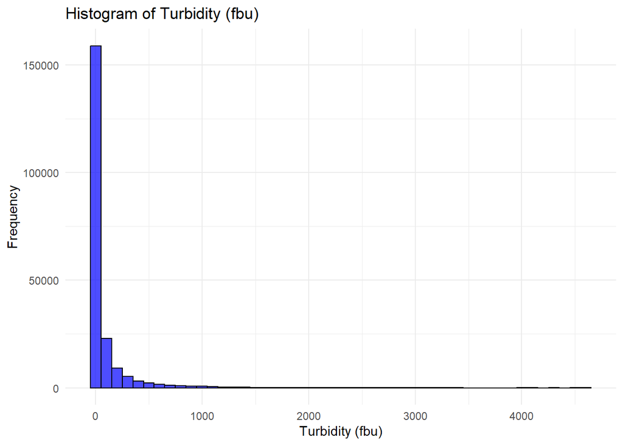

```r
ggplot(joined_data, aes(x = turbidity_fbu)) +
  geom_histogram(binwidth = 100, fill = "blue", color = "black", alpha = 0.7) +
  labs(title = "Histogram of Turbidity (fbu)", x = "Turbidity (fbu)", y = "Frequency") +
  theme_minimal()
```

```r
#kolmogorov nromality test (very high n dataset)
kstest_Q <- ks.test(joined_data$discharge_cfs, "pnorm", mean=mean(joined_data$discharge_cfs), sd=sd(joined_data$discharge_cfs))
kstest_turb <- ks.test(joined_data$turbidity_fbu, "pnorm", mean=mean(joined_data$turbidity_fbu), sd=sd(joined_data$turbidity_fbu))
print(kstest_Q)
```

```
    Asymptotic one-sample Kolmogorov-Smirnov test

data:  joined_data$discharge_cfs
D = 0.18581, p-value < 2.2e-16
alternative hypothesis: two-sided
```

```r
print(kstest_turb)
```

```
    Asymptotic one-sample Kolmogorov-Smirnov test

data:  joined_data$turbidity_fbu
D = 0.36381, p-value < 2.2e-16
alternative hypothesis: two-sided
```

For our initial visualizations, we have plotted both parameters (discharge and turbidity) on the same plot, allowing us to visually interpret our data, and initially analyze whether there is correlation between our streamflow (Q) and turbidity levels. Additionally, in order to visually assess the distribution of our data, we made histograms which demonstrated very strong right skewing in both parameters, indicating that we should test for normality and likely keep the normality of our data in mind for future analyses. Our Kolmogorov test was a solution we found to our dataset being very large, resulting in needing this test to determine if our data was normal. Our results indicating the strong right skew (non-normal) we expected from our previous plots (p values < 2.2e-16).

## Stat Test

```
In [4]:
```

```r
#perform spearmans rank corr test
spearman_corr <- cor.test(joined_data$discharge_cfs, joined_data$turbidity_fbu, method = "spearman")
#linear regression on both parameters
lm <- lm(discharge_cfs ~ turbidity_fbu, data = joined_data)

print(spearman_corr)
```

```
    Spearman's rank correlation rho

data:  joined_data$discharge_cfs and joined_data$turbidity_fbu
S = 6.1836e+14, p-value < 2.2e-16
alternative hypothesis: true rho is not equal to 0
sample estimates:
      rho
0.5981768
```

```r
print("r squared")
```

[output not shown]

```r
print(lm)
```

```
Call:
lm(formula = discharge_cfs ~ turbidity_fbu, data = joined_data)

Coefficients:
  (Intercept)  turbidity_fbu
     1279.873          2.451
```

## Preliminary Methods

1.) Identify your preliminary methods Our preliminary methods, as seen above, are EDA and then initial tests of Spearman’s Correlation and Linear Regression in order to initially determine if there is a relationship between our two parameters. Further into our work we will be looking to integrate time into our perspectives and analyses, which will allow us to better understand how closely related our two parameters are as well as how closely they are linked on a temporal scale. One of our ideas for investigating this would be to test how time as affected turbidity after the dam removal, which would allow us to better visualize and understand how sediments are being transported from the reservoir downstream, and how this process is changing as time moves on after the removal.

2.) What are you thinking about using to analyze your data to answer your question? We are still working on determining our statistical methods but we are certain one of our next steps in analysis should be to determine th relationship of time and turbidity, controlling for discharge. This will allow us to better understand how turbidity continues to change post dam-removal.

3.) Do you have everything you need? What supplemental data might you need? Unfortunately our study is very specific case-wise, so there is no more available data within this watershed relating to the period of the dam removal, but there is a possibility we could integrated parallel data for other dam removals if we were able to find appropriate data.

4.) What are some potential challenges you see in the data? One issue we have found in our data so far is that the period of record for our discharge and turbidity are relatively short on the timescale of the dam removal. Ideally we would have captured turbidity levels before, during, and after the dam removal so that we could additionally analyse geomorphology regime changes but unfortunately this was not possible.

5.) What are some potential challenges you see in the methods? One challenge we have already found when investigating our data initially is that we have pairs in our data that is complicating our Spearman’s rank correlation test. This has caused problems because it complicates the Spearman’s correlation resulting p value into a estimation. In this way, we may need to find a different correlation method to use if this is a big enough issue.

6.) How do the selected methods help you get to your final goal? Ultimately our selected methods allow us to get further by describing and enlightening the relationship between discharge and turbidity levels in the Elwha River specifically below the Glines Canyon Dam Removal site. The analyses and plans we have will allow us to investigate how the relationship works, how it has changed, and how time has impacted this relationship post-dam removal.

Bednarek, A. T. (2001). Undamming rivers: A review of the ecological impacts of dam removal. *Environmental Management*, *27*, 803–814.

Duda, J. J., Freilich, J. E., & Schreiner, E. G. (2008). Baseline studies in the elwha river ecosystem prior to dam removal: Introduction to the special issue. *Northwest Science*, *82*(sp1), 1–12.

Duda, J. J., Warrick, J. A., & Magirl, C. S. (2011). Coastal and lower elwha river, washington, prior to dam removal—history, status, and defining characteristics. *Coastal Habitats of the Elwha River, Washington—Biological and Physical Patterns and Processes Prior to Dam Removal. US Geological Survey Scientific Investigations Report*, *5120*, 1–26.

Graf, W. (1993). *Sustaining our water resources*.

Hart, D. D., Johnson, T. E., Bushaw-Newton, K. L., Horwitz, R. J., Bednarek, A. T., Charles, D. F., Kreeger, D. A., & Velinsky, D. J. (2002). Dam removal: Challenges and opportunities for ecological research and river restoration: We develop a risk assessment framework for understanding how potential responses to dam removal vary with dam and watershed characteristics, which can lead to more effective use of this restoration method. *BioScience*, *52*(8), 669–682.

Johnson, S. (2001). Kettle river dam removal: Impacts of sediment on downstream mussel populations. *A Meeting of the Freshwater Mollusk Conservation Society*.

Mishra, P., Pandey, C. M., Singh, U., Gupta, A., Sahu, C., & Keshri, A. (2019). Descriptive statistics and normality tests for statistical data. *Annals of Cardiac Anaesthesia*, *22*(1), 67–72.

Simons, R. K., & Simons, D. B. (1991). Sediment problems associated with dam removal, muskegon river, michigan. *Hydraulic Engineering*, 680–685.